# ExtraaLearn: Lead Intelligence System

### XGBoost (Tuned)

XGBoost is the next step up -- faster, more tuning knobs, and the go-to gradient boosting library in practice. It doesn't accept `class_weight`, so class imbalance is handled with `scale_pos_weight` instead.

Using `RandomizedSearchCV` here because the search space is large enough that an exhaustive grid would be wasteful. Fifty random combinations give good coverage at a fraction of the cost.

Tuning n_estimators, learning rate, depth, subsample, colsample_bytree, and scale_pos_weight. `colsample_bytree` is new -- it controls how many features each tree can see, which helps reduce overfitting.

```
Scale Pos Weight: 2.3485
Fitting 5 folds for each of 50 candidates, totalling 250 fits
Best Parameters:
{'classifier__subsample': 0.9, 'classifier__scale_pos_weight': np.float64(2.935684647302905), 'classifier__n_estimators': 100, 'classifier__max_depth': 4, 'classifier__learning_rate': 0.05, 'classifier__colsample_bytree': 0.7}

Best CV ROC-AUC: 0.9270
              precision    recall  f1-score   support

           0       0.94      0.83      0.88       971
           1       0.69      0.88      0.77       413

    accuracy                           0.84      1384
   macro avg       0.81      0.85      0.83      1384
weighted avg       0.87      0.84      0.85      1384

ROC-AUC: 0.9270
```

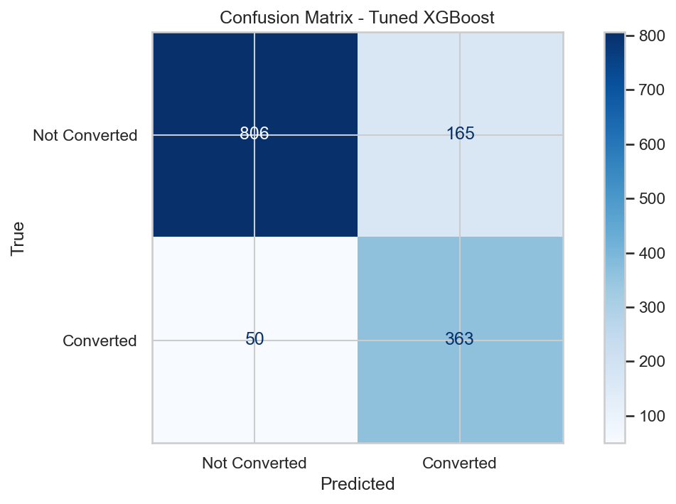

```python
# Imbalance ratio gives more weight to the converted leads during training
negative_count = (y_train == 0).sum()
positive_count = (y_train == 1).sum()
scale_pos_weight = negative_count / positive_count
print(f'Scale Pos Weight: {scale_pos_weight:.4f}')

xgb_pipe = Pipeline(steps=[
    ('preprocessor', preprocessor),
    ('classifier', XGBClassifier(
        objective='binary:logistic',
        eval_metric='logloss',
        random_state=42,
        n_jobs=-1
    ))
])

param_distributions = {
    'classifier__n_estimators': [100, 300, 500],
    'classifier__learning_rate': [0.01, 0.05, 0.1],
    'classifier__max_depth': [2, 3, 4],
    'classifier__subsample': [0.7, 0.8, 0.9, 1.0],
    'classifier__colsample_bytree': [0.7, 0.8, 0.9, 1.0],
    'classifier__scale_pos_weight': [
        1,
        scale_pos_weight * 0.75,
        scale_pos_weight,
        scale_pos_weight * 1.25
    ]
}

stratified_cv = StratifiedKFold(n_splits=5, shuffle=True, random_state=42)

xgb_random = RandomizedSearchCV(
    estimator=xgb_pipe,
    param_distributions=param_distributions,
    n_iter=50,
    scoring='roc_auc',
    cv=stratified_cv,
    n_jobs=-1,
    random_state=42,
    verbose=1
)

xgb_random.fit(X_train, y_train)

print('Best Parameters:')
print(xgb_random.best_params_)
print(f'\nBest CV ROC-AUC: {xgb_random.best_score_:.4f}')

best_xgb_model = xgb_random.best_estimator_
y_pred_xgb = best_xgb_model.predict(X_test)

print(classification_report(y_test, y_pred_xgb))
roc_auc_xgb = roc_auc_score(y_test, best_xgb_model.predict_proba(X_test)[:, 1])
print(f'ROC-AUC: {roc_auc_xgb:.4f}')

show_confusion(y_test, y_pred_xgb, 'Confusion Matrix - Tuned XGBoost')
```

#### Observations

XGBoost ties tuned GB on F1 (0.77) but gets there with a different mix -- recall hits 0.88, the highest of any model, while precision drops to 0.69. ROC-AUC of 0.927 is essentially a tie with tuned GB (0.929).

The chosen params look reasonable: learning rate 0.05, depth 4, 100 trees, subsample 0.9, colsample_bytree 0.7. RandomizedSearchCV also picked a `scale_pos_weight` higher than the natural imbalance ratio (2.94 vs 2.35), which is what pushed recall up further.

Two more practical points worth flagging:

1. XGBoost trained the full 50-iter randomized search much faster than the GB grid search ran. If retraining cadence matters, that's a real win.
2. The recall/precision profile here favors the recall side harder than tuned GB. For lead scoring, that's likely the right shape.

### Final Model Selection

Picking **XGBoost** as the final model.

Tuned GB edges it on ROC-AUC by 0.002, which isn't a meaningful gap. XGBoost wins on the metrics that matter for this problem:

- **Recall of 0.88** -- the strongest converter capture across all models
- **Much faster to train and retune**, which matters if this gets put into any kind of refresh cadence

The extra false positives that come with higher recall are cheap here -- a sales rep makes an extra call that doesn't close. Missing a real converter is the expensive outcome, and XGBoost minimizes that better than anything else tested.

## Model Evaluation

This section brings together the results from all models to confirm and visualize the decision to select XGBoost as the final model.

The evaluation includes:

- Comparison table of key metrics
- ROC curves: all models overlaid on a single chart
- Precision-Recall curves: all models overlaid on a single chart

### Results Comparison

```python
# Build comparison table directly from the fitted models so it stays in sync
models = {
    'Logistic Regression': lr_pipe,
    'Decision Tree': dt_pipe,
    'Random Forest': rf_pipe,
    'Gradient Boosting (Tuned)': gb_grid.best_estimator_,
    'XGBoost (Tuned)': xgb_random.best_estimator_
}

rows = {}
for name, m in models.items():
    pred = m.predict(X_test)
    proba = m.predict_proba(X_test)[:, 1]
    rows[name] = {
        'Precision': precision_score(y_test, pred),
        'Recall': recall_score(y_test, pred),
        'F1': f1_score(y_test, pred),
        'Accuracy': (pred == y_test).mean(),
        'ROC-AUC': roc_auc_score(y_test, proba)
    }

model_comparison_df = pd.DataFrame(rows).T

# Highlight the best score per column
model_comparison_df.style.highlight_max(
    axis=0,
    props='background-color: #c6efce; color: #1a5c2e; font-weight: bold'
).format('{:.4f}')
```

|  | Precision | Recall | F1 | Accuracy | ROC-AUC |
| --- | --- | --- | --- | --- | --- |
| Logistic Regression | 0.6296 | 0.8232 | 0.7135 | 0.8027 | 0.8779 |
| Decision Tree | 0.6698 | 0.6925 | 0.6810 | 0.8064 | 0.7735 |
| Random Forest | 0.7869 | 0.6973 | 0.7394 | 0.8533 | 0.9142 |
| Gradient Boosting (Tuned) | 0.7062 | 0.8499 | 0.7714 | 0.8497 | 0.9293 |
| XGBoost (Tuned) | 0.6875 | 0.8789 | 0.7715 | 0.8447 | 0.9270 |

#### ROC Curves

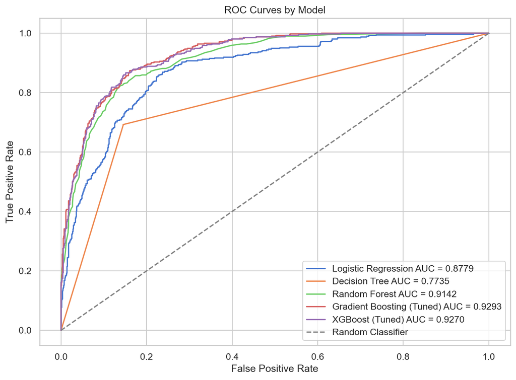

```python
# Reuse the same fitted models list across ROC and PR curves
eval_models = [
    ('Logistic Regression', lr_pipe),
    ('Decision Tree', dt_pipe),
    ('Random Forest', rf_pipe),
    ('Gradient Boosting (Tuned)', gb_grid.best_estimator_),
    ('XGBoost (Tuned)', xgb_random.best_estimator_)
]

plt.figure(figsize=(10, 7))
for model_name, model in eval_models:
    y_pred_proba = model.predict_proba(X_test)[:, 1]
    fpr, tpr, _ = roc_curve(y_test, y_pred_proba)
    auc_score = roc_auc_score(y_test, y_pred_proba)
    plt.plot(fpr, tpr, label=f'{model_name} AUC = {auc_score:.4f}')

plt.plot([0, 1], [0, 1], linestyle='--', color='grey', label='Random Classifier')
plt.title('ROC Curves by Model')
plt.xlabel('False Positive Rate')
plt.ylabel('True Positive Rate')
plt.legend(loc='lower right')
plt.grid(True)
plt.show()
```

#### Observations

The Decision Tree curve is visibly more angular than the others -- a single tree only has a handful of distinct probability values coming out of its leaf nodes, so the curve steps rather than smooths. The ensembles average predictions across many trees, which fills in the curve.

#### Precision-Recall Curves

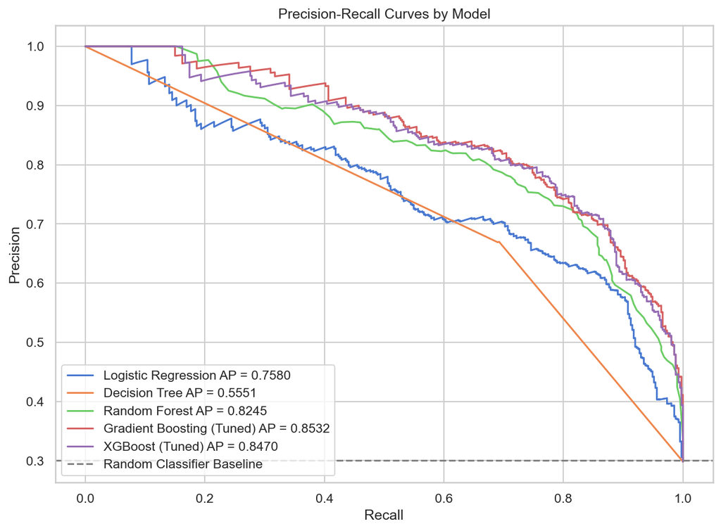

```python
# PR curves reuse the eval_models list defined above
plt.figure(figsize=(10, 7))
for model_name, model in eval_models:
    y_pred_proba = model.predict_proba(X_test)[:, 1]
    precision, recall, _ = precision_recall_curve(y_test, y_pred_proba)
    pr_score = average_precision_score(y_test, y_pred_proba)
    plt.plot(recall, precision, label=f'{model_name} AP = {pr_score:.4f}')

# Baseline is the positive class rate (~0.30 here)
plt.axhline(y=0.30, linestyle='--', color='grey', label='Random Classifier Baseline')
plt.title('Precision-Recall Curves by Model')
plt.xlabel('Recall')
plt.ylabel('Precision')
plt.legend(loc='lower left')
plt.grid(True)
plt.show()
```

#### Observations

Precision falls as recall rises across all models, which is expected -- as the threshold drops to capture more converters, more non-converters get pulled in too. The ensemble models hold their precision well into the high-recall zone, which is where this problem lives. Same angular pattern shows up in the Decision Tree curve for the same reason as the ROC plot.

## Feature Importance & Explainability

SHAP is used to explain how each feature contributes to the model’s predictions. It shows which variables push a prediction higher or lower and how strongly they influence the outcome.

For this business problem, SHAP helps translate the XGBoost model from a prediction tool into something more actionable by showing what factors are most associated with lead conversion. This section reviews global feature importance across the model and then looks at individual predictions to understand what drives specific conversion outcomes.

```python
# Extract the preprocessor and classifier from the final pipeline
preprocessor_step = best_xgb_model.named_steps["preprocessor"]

xgb_classifier = best_xgb_model.named_steps["classifier"]

# Transform X_test using the fitted preprocessor
X_test_transformed = preprocessor_step.transform(X_test)

# Get feature names after preprocessing / encoding
feature_names = preprocessor_step.get_feature_names_out()
```

```python
# Convert transformed X_test into a DataFrame so SHAP keeps feature names
X_test_transformed_df = pd.DataFrame(
    X_test_transformed,
    columns=feature_names,
    index=X_test.index
)

# Build SHAP explainer and calculate SHAP values
explainer = shap.TreeExplainer(xgb_classifier)
shap_values = explainer(X_test_transformed_df)
```

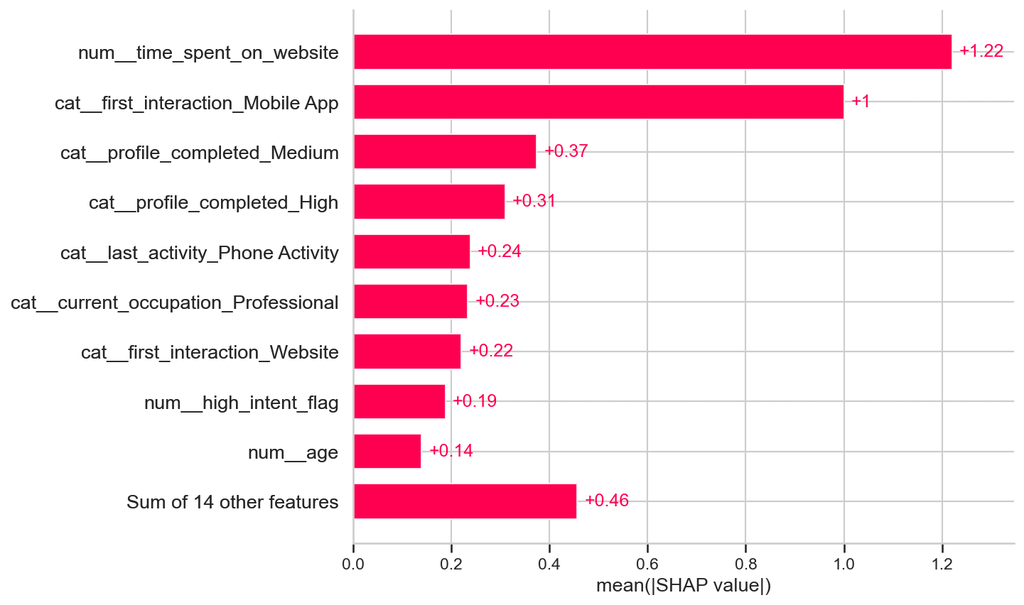

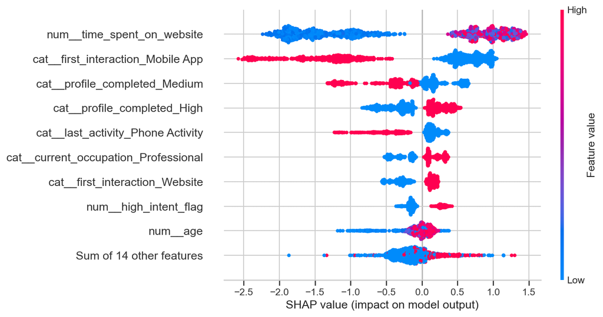

```python
# Create SHAP plots
shap.plots.bar(shap_values)
shap.plots.beeswarm(shap_values)
```

#### SHAP Observations

The bar plot ranks features by mean absolute SHAP value -- a clean view of which features move the model's predictions the most, regardless of direction. The beeswarm plot adds the direction back in by showing how each feature's actual values translate into push toward or away from conversion.

**Top drivers of conversion:**

- `time_spent_on_website` -- most influential overall, with longer sessions pushing predictions toward conversion
- `first_interaction = Website` -- web-first leads convert at higher rates than mobile-first ones
- `profile_completed = High` -- complete profiles are a strong positive signal
- `current_occupation = Professional` -- professionals convert more than students or unemployed leads
- `high_intent_flag` -- the engineered feature paid off, it's near the top

**Pushing the other direction:**

- `first_interaction = Mobile App` and `last_activity = Phone Activity` both consistently lower the conversion probability
- `profile_completed = Medium` doesn't help either -- partial signals look more like noise than commitment

The story is straightforward: leads who showed up via the website, filled out their profile, and spent real time on the site are the ones worth calling first. Mobile and phone-only patterns need more nurturing before they're ready.

## Lead Scoring & Priority Tiers

The XGBoost model outputs a probability for every lead. A binary predict/don't-predict answer throws most of that signal away -- a lead at 0.91 and a lead at 0.51 both come back as "yes" and the sales team can't tell them apart. Bucketing the predicted probabilities into Hot, Warm, Nurture, and Low tiers preserves the ranking, gives reps a prioritized list, and makes the threshold choices explicit instead of hidden inside the model.

```python
# Score the test set with the final XGBoost model
test_probs = best_xgb_model.predict_proba(X_test)[:, 1]

# Bin probabilities into priority tiers
# right=False so 0.75 lands in Hot, 0.50 in Warm, 0.25 in Nurture
tier_bins = [0, 0.25, 0.50, 0.75, 1.01]
tier_labels = ['Low', 'Nurture', 'Warm', 'Hot']

lead_scores = pd.DataFrame({
    'actual': y_test.values,
    'probability': test_probs,
    'tier': pd.cut(test_probs, bins=tier_bins, labels=tier_labels, right=False, include_lowest=True)
}, index=X_test.index)

lead_scores.head()
```

|  | actual | probability | tier |
| --- | --- | --- | --- |
| 515 | 0 | 0.03 | Low |
| 4313 | 0 | 0.01 | Low |
| 1286 | 0 | 0.05 | Low |
| 3375 | 1 | 0.94 | Hot |
| 186 | 0 | 0.03 | Low |

```python
# Summarize leads by tier
tier_summary = lead_scores.groupby('tier', observed=True).agg(
    **{'Lead Count': ('actual', 'size'),
       '% of Test Set': ('actual', lambda s: len(s) / len(lead_scores) * 100),
       'Conversion Rate': ('actual', 'mean')}
)

tier_summary['% of Test Set'] = tier_summary['% of Test Set'].round(1)
tier_summary['Conversion Rate'] = (tier_summary['Conversion Rate'] * 100).round(1)

tier_summary
```

| tier | Lead Count | % of Test Set | Conversion Rate |
| --- | --- | --- | --- |
| Low | 574 | 41.50 | 1.40 |
| Nurture | 282 | 20.40 | 14.90 |
| Warm | 150 | 10.80 | 40.70 |
| Hot | 378 | 27.30 | 79.90 |

```python
hot_capture = lead_scores[lead_scores['tier'] == 'Hot']['actual'].sum()
total_converters = lead_scores['actual'].sum()
print(f"Hot tier captures {hot_capture} of {total_converters} converters "
      f"({hot_capture / total_converters * 100:.1f}%)")
```

```
Hot tier captures 302 of 413 converters (73.1%)
```

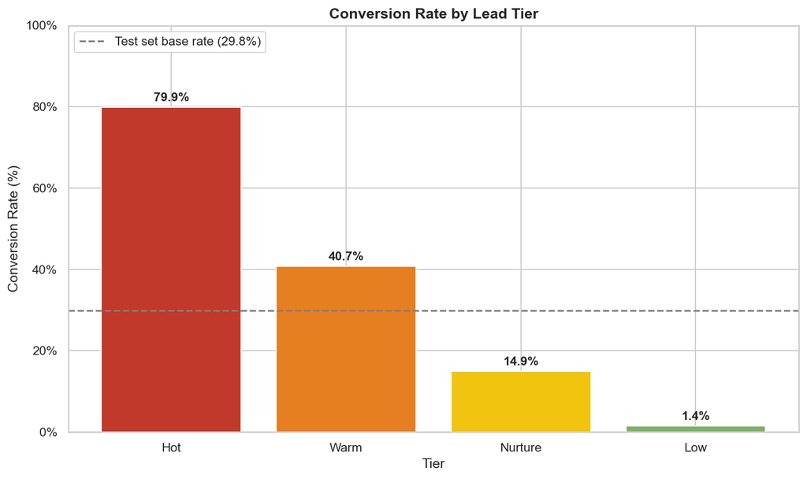

```python
# Plot conversion rate by tier with the base rate as reference
base_rate = lead_scores['actual'].mean() * 100

fig, ax = plt.subplots(figsize=(10, 6))
bars = ax.bar(
    tier_summary.index[::-1].astype(str),
    tier_summary['Conversion Rate'][::-1],
    color=['#c0392b', '#e67e22', '#f1c40f', '#7fb069']  # no reverse needed
)

# Value labels on top of each bar
for bar in bars:
    h = bar.get_height()
    ax.text(bar.get_x() + bar.get_width() / 2, h + 1.5, f'{h:.1f}%',
            ha='center', fontsize=11, fontweight='bold')

# Base rate reference line
ax.axhline(base_rate, linestyle='--', color='grey',
           label=f'Test set base rate ({base_rate:.1f}%)')

ax.set_title('Conversion Rate by Lead Tier', fontsize=13, fontweight='bold')
ax.set_xlabel('Tier')
ax.set_ylabel('Conversion Rate (%)')
ax.set_ylim(0, 100)
ax.yaxis.set_major_formatter(mtick.PercentFormatter(decimals=0))
ax.legend(loc='upper left')
plt.tight_layout()
plt.show()
```

#### Observations

The tier conversion rates land exactly where they should: Hot at 79.9%, Warm at 40.7%, Nurture at 14.9%, Low at 1.4%. EEach tier clears the next one by a clean margin, and only Hot and Warm sit above the 29.8% base rate. That's real separation -- the model isn't just predicting, it's ranking.

**For the sales team:** Hot is 27% of the pipeline and captures 73% of the actual converters. Working that bucket first means roughly three out of four real customers come from less than a third of the lead volume. Warm is the second pass -- still well above base rate at 41%, worth working but with lower expected yield per call.

**For Nurture:** 15% conversion is below base rate but it's not noise. These leads have real but incomplete signal -- partial profile, lower engagement, or both. The right move is automation: drip email, retargeting, or a delayed second touch. Cheap to keep warm, not cheap enough to call cold.

Low at 1.4% is essentially dead. Don't spend sales time here. If marketing wants to keep them in a long-cycle nurture program that's fine, but they're not a sales priority.

## Recommendations

```python
# Validate high_intent_flag conversion lift on the test set
# (cell 83 ran this on the full dataset -- this confirms the signal holds on test)
test_lift = pd.DataFrame({
    'high_intent_flag': X_test['high_intent_flag'].values,
    'converted': y_test.values
})

flag_summary = test_lift.groupby('high_intent_flag')['converted'].agg(
    lead_count='size',
    conversion_rate='mean'
)
flag_summary['conversion_rate'] = (flag_summary['conversion_rate'] * 100).round(1)
flag_summary.index = ['Low Intent', 'High Intent']

flag_summary
```

|  | lead_count | conversion_rate |
| --- | --- | --- |
| Low Intent | 1026 | 21.30 |
| High Intent | 358 | 54.20 |

### Sales

- **Work the Hot tier first, every day.** It's 27% of the pipeline and captures 73% of real converters. SLA the response time -- ideally first contact within 24 hours of the lead crossing 0.75.
- **Warm tier (40.7% conversion) is the second pass.** Real opportunity, lower yield per call. Slot into the calendar after Hot is cleared.
- **Don't manually work Nurture or Low.** Hand them to marketing automation. The probability score is already a routing decision -- use it.
- **Use the raw probability for tie-breaks within Hot.** A lead at 0.94 and one at 0.76 are both Hot, but they're not the same. Call the higher one first.

## Conclusions & Executive Summary

ExtraaLearn's sales team is working a growing pool of leads with no reliable way to tell which ones are worth calling first. Treating every lead the same wastes time on prospects who won't convert and lets real customers cool off in the queue. This project built a Lead Intelligence System that takes the raw lead data ExtraaLearn already collects -- demographics, site behavior, channel exposure, profile completion -- and turns it into a prioritized list with a probability score for every lead. The result is a sales workflow built around the leads most likely to convert, not the leads that happen to land in the queue first.

### Key Findings

**Engagement is the strongest signal in the data.** Time spent on the website is the most influential feature across every model, and it shows up as the top SHAP driver in the final XGBoost model. Leads who spend real time on the site convert at a meaningfully higher rate than those who don't, regardless of how they were acquired.

**Profile completion separates serious leads from casual ones.** Leads who fully completed their profile converted at much higher rates than those who only partially filled it out. The engineered `high_intent_flag` -- a combination of high profile completion and above-median time on site -- captured this pattern in a single feature and converted at roughly 2.5x the rate of leads without the flag.

**How a lead first interacts with ExtraaLearn matters more than how much marketing they see.** First interaction through the website is consistently associated with higher conversion than first interaction through the mobile app, while paid channels (print, digital, educational) show only weak signal on conversion. The acquisition channel that gets a lead to the website -- and into a real session -- is more valuable than the channel that simply gets a lead's attention.

### Final Model

XGBoost was selected as the final model. On the held-out test set it achieved:

- **Recall of 0.88** -- of all the leads that actually converted, the model correctly identified 88% of them
- **Precision of 0.69** -- of the leads the model flagged as converters, 69% actually did
- **ROC-AUC of 0.927** -- strong ranking ability, the model reliably scores real converters higher than non-converters

The metric that matters most here is recall. A false positive -- a lead that gets called and doesn't close -- costs the sales team a few minutes. A false negative -- a real customer who never gets prioritized -- costs ExtraaLearn the entire deal. The model is tuned to lean toward catching converters, accepting some extra outreach in exchange for missing fewer real opportunities.

### Lead Scoring Output

The final deliverable is a tiering system that turns every model probability into a sales action. Leads are scored on a 0-1 probability and bucketed into Hot (≥ 0.75), Warm (0.50-0.74), Nurture (0.25-0.49), and Low (< 0.25). On the test set, conversion rates landed at 80%, 41%, 15%, and 1% respectively -- each tier well-separated from the next. The Hot tier alone accounted for 27% of the pipeline and captured 73% of all actual converters, meaning the sales team can focus on just over a quarter of incoming leads and still capture three out of four real customers.

### Limitations & Caveats

A few things worth flagging before this gets put into production:

## Appendix: Data Dictionary

### Original Features

| Column | Type | Description |
| --- | --- | --- |
| `ID` | string | Unique lead identifier. Dropped before modeling — no predictive value. |
| `age` | int | Lead age in years. Range: 18–63. |
| `current_occupation` | categorical | Employment status: Professional, Student, Unemployed. |
| `first_interaction` | categorical | Channel of first contact: Website, Mobile App. |
| `profile_completed` | categorical | Profile completion level: High, Medium, Low. |
| `website_visits` | int | Number of visits to the ExtraaLearn website. Outliers clipped at IQR upper bound (9.5). |
| `time_spent_on_website` | int | Total time spent on the website across all visits. Unit assumed to be minutes — not explicitly defined in the source data. Outliers: none detected. |
| `page_views_per_visit` | float | Average pages viewed per website visit. Outliers clipped at IQR upper bound (6.27). |
| `last_activity` | categorical | Most recent interaction type: Website Activity, Email Activity, Phone Activity. |
| `print_media_type1` | binary | Exposed to Type 1 print advertising (newspaper). Original: Yes/No. Encoded: 1/0. |
| `print_media_type2` | binary | Exposed to Type 2 print advertising (magazine). Original: Yes/No. Encoded: 1/0. |
| `digital_media` | binary | Exposed to digital media advertising. Original: Yes/No. Encoded: 1/0. |
| `educational_channels` | binary | Reached through educational channel advertising. Original: Yes/No. Encoded: 1/0. |
| `referral` | binary | Lead came through a referral. Original: Yes/No. Encoded: 1/0. |
| `status` | binary | **Target variable.** 1 = converted to paying customer, 0 = not converted. Class split: 70.1% not converted, 29.9% converted. |

### Engineered Features

[output not shown]